# MIGRATION MAP

Mencía Gómez-Luna

2025-01-10

We open the libraries that we’ll use

```r
library(readxl)
library(openxlsx)
library(dplyr)
```

```r
library(ggplot2)
library(rworldmap)
library(sf)
library(ggforce)
library(gridExtra)
library(grid)
library(sysfonts)
library(showtext)
library(showtextdb)
library(png)
library(cowplot)
library(ggforce)
#and fonts
font_add_google("Lato", family = "lato")
font_add_google("Raleway", family = "raleway")
knitr::opts_chunk$set(fig.showtext = TRUE)
showtext_auto()
```

## PREPARE THE DATA

We load the data and the base map

```r
# DATA
datos <- read.xlsx("C:/Users/menci/OneDrive/Escritorio/R STUDIO/DATA VISUALIZATION/TRABAJO FINAL/migraciones_final.xlsx", sheet = 1)

# BASE MAP
mapa_mundial <- st_as_sf(getMap(resolution = "low"))
mapa_mundial <- mapa_mundial |>
  rename(Country = ADMIN)
```

Then we join our data (and change some country names)

```r
datos_mapa <- mapa_mundial |>
  left_join(datos, by = "Country")

datos_mapa <- datos_mapa |>
  mutate(Country = recode(Country, "United Arab Emirates" = "EAU"),
         Country = recode(Country, "British Virgin Islands" = "BVI"))
```

We create the brackets for the “% of immigrants”

```r
datos_mapa$Percent_Migration <- datos_mapa$Percent_Migration * 100

datos_mapa$Percent_Migration_category <- cut(
  datos_mapa$Percent_Migration,
  breaks = c(-Inf, 1, 3, 10, 25, Inf),
  labels = c("< 1%", "1% - 3%", "3% - 10%", "10% - 25%", ">25%"),
  right = FALSE
)
```

## We create the first **MAP**

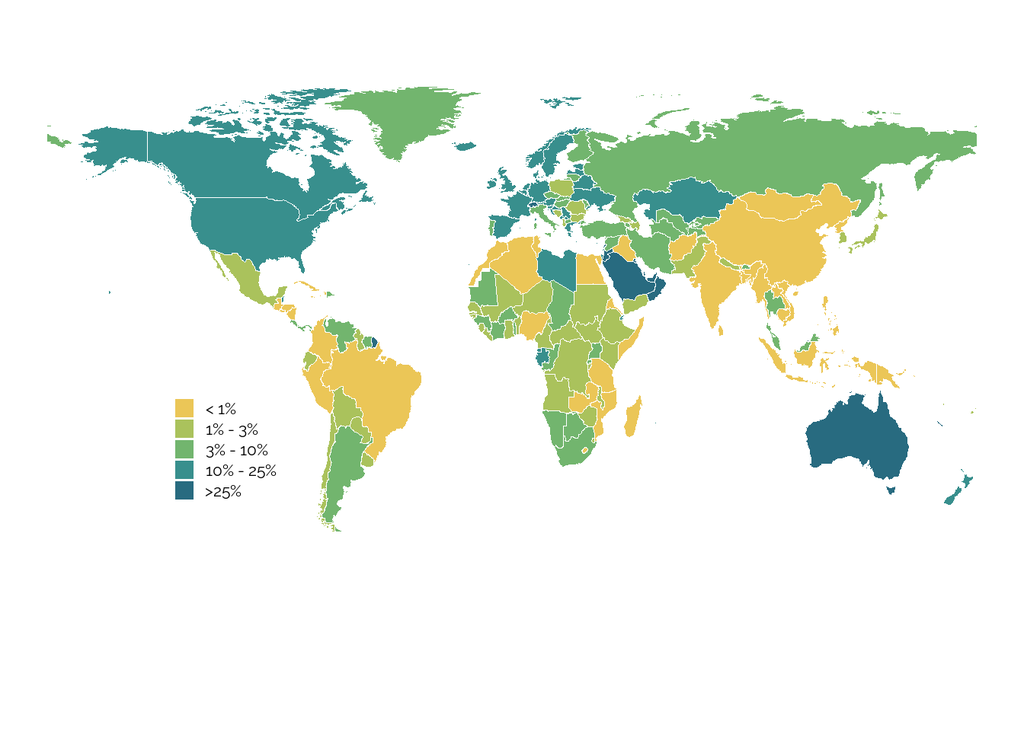

```r
original_map <- ggplot(datos_mapa) +
  geom_sf(aes(fill = Percent_Migration_category), color = "white", linewidth = 0.25) +
  scale_fill_manual(
    values = c("< 1%" = "#ebc657", "1% - 3%" = "#aac25c","3% - 10%" = "#72b56e",
               "10% - 25%" = "#388f8d", ">25%" = "#286b80"),
    name = "% de población migrante",
    na.value = "#e1e1e1",
    na.translate = FALSE,
    guide = guide_legend(
      keywidth = 0.7,  # Legend width
      keyheight = 0.7, # Legend height
    )
  ) +
  theme_void() +
  theme(
    legend.position = c(0.17, 0.28),  # Legend position
    legend.justification = c(0, 0),
    legend.title = element_blank(),
    legend.text = element_text(size = 8 , family = "raleway"))+
  coord_sf()+
  theme(aspect.ratio = 0.6)
original_map
```

## We create the **BARPLOT**

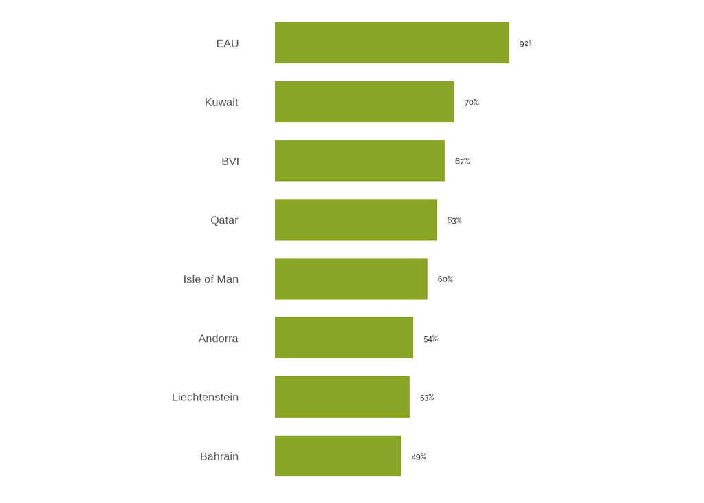

```r
barplot <- datos_mapa |>
  arrange(desc(Percent_Migration)) |>
  head(8) |>
  ggplot(aes(x = reorder(Country, Percent_Migration), y = Percent_Migration, fill = Percent_Migration)) +
  geom_bar(stat = "identity", fill="#8aa526",  width = 0.7) +
  geom_text(
    aes(label = paste0(round(Percent_Migration), "%")),
    hjust = 0,  # Text position
    nudge_y = 4, #Space between bars and percentage
    size = 2,
    family = "raleway"
  )+
  coord_flip() +  # Horizontal
  scale_y_continuous(expand = expansion(mult = c(0.05, 0.05)))+ #Space between bars
  theme_minimal() +
  theme(
    axis.text.x = element_blank(),  # Eliminate text in axis X
    axis.text.y = element_text(size = 8,  margin = margin(r = 15)),   # Margin (for the flags)
    axis.title.x = element_blank(),  # Eliminate the title in axis X
    axis.title.y = element_blank(),  # Eliminate the title in axis X
    panel.grid = element_blank(),
    axis.line = element_blank(),
    legend.position = "none",
    aspect.ratio = 1.8 #more or less compressed
  )
barplot
```

> **IMPORTANT**: The letters are small so that in the final join with the map the letters are a good size. And the margin between the Y axis and the bars is wide to add the flag images.

> So, next, we want to add the flags, so we load them and add them

```r
flag_eau <- readPNG("C:/Users/menci/OneDrive/Escritorio/R STUDIO/DATA VISUALIZATION/TRABAJO FINAL/BANDERAS/EAU.png")
flag_kuwait <- readPNG("C:/Users/menci/OneDrive/Escritorio/R STUDIO/DATA VISUALIZATION/TRABAJO FINAL/BANDERAS/Kuwait.png")
flag_bvi <- readPNG ("C:/Users/menci/OneDrive/Escritorio/R STUDIO/DATA VISUALIZATION/TRABAJO FINAL/BANDERAS/british.png")
flag_qatar <- readPNG ("C:/Users/menci/OneDrive/Escritorio/R STUDIO/DATA VISUALIZATION/TRABAJO FINAL/BANDERAS/Catar.png")
flag_isleofman <- readPNG ("C:/Users/menci/OneDrive/Escritorio/R STUDIO/DATA VISUALIZATION/TRABAJO FINAL/BANDERAS/islaman.svg.png")
flag_andorra <- readPNG ("C:/Users/menci/OneDrive/Escritorio/R STUDIO/DATA VISUALIZATION/TRABAJO FINAL/BANDERAS/andorra.png")
flag_liecht <- readPNG ("C:/Users/menci/OneDrive/Escritorio/R STUDIO/DATA VISUALIZATION/TRABAJO FINAL/BANDERAS/lichtenstein.png")
flag_bahrain <- readPNG ("C:/Users/menci/OneDrive/Escritorio/R STUDIO/DATA VISUALIZATION/TRABAJO FINAL/BANDERAS/Barein.png")
```

> Final bar plot with the flags:

```r
graph <- barplot +
  annotation_raster(flag_eau, xmin = 7.65, xmax = 8.35, ymin = -32, ymax = -6)+
  annotation_raster(flag_kuwait, xmin = 6.65, xmax = 7.35, ymin = -32, ymax = -6)+
  annotation_raster(flag_bvi, xmin = 5.65, xmax = 6.35, ymin = -32, ymax = -6) +
  annotation_raster(flag_qatar, xmin = 4.65, xmax = 5.35, ymin = -32, ymax = -6) +
  annotation_raster(flag_isleofman, xmin = 3.65, xmax = 4.35, ymin = -32, ymax = -6) +
  annotation_raster(flag_andorra, xmin = 2.65, xmax = 3.35, ymin = -32, ymax = -6) +
  annotation_raster(flag_liecht, xmin = 1.65, xmax = 2.35, ymin = -32, ymax = -6) +
  annotation_raster(flag_bahrain, xmin = 0.65, xmax = 1.35, ymin = -32, ymax = -6) +
  coord_flip(clip = "off")
```

[output not shown]

[figure not shown]

```r
graph
```

> The reason why I didn’t correct the superimposition of maps on the letters and graphics is because in the final join it it reajusts automatically and fits good

# FINAL REPLICATION

> Now we want to join the map with the barplot and add the logo, title and source. So first we load the images for the logo and image and transform the map and barplot into a grob plot. The grob command allows us to directly manipulate graphical elements so it’ss useful for combining complex plots outside of standard ggplot2 capabilities:

```r
#We load the logo and image to add
logo <- readPNG("C:/Users/menci/OneDrive/Escritorio/R STUDIO/DATA VISUALIZATION/TRABAJO FINAL/EOM.png")
image <- readPNG ("C:/Users/menci/OneDrive/Escritorio/R STUDIO/DATA VISUALIZATION/TRABAJO FINAL/familia2.png")

#Transform into grob
map_grob <- ggplotGrob(original_map)
graph_grob <- ggplotGrob(graph)
```

> We join map + barplot + source + images + title:

[figure not shown]

```r
plot <- ggdraw() +
  draw_grob(map_grob) +
  draw_grob(graph_grob, x = 0.46, y = 0.14, width = 0.35, height = 0.25) +
  draw_image(logo, x = 0.77, y = 0.08, width = 0.12, height = 0.14) +
  draw_image(image, x = 0.82, y = 0.90, width = 0.12, height = 0.11) +
  draw_grob(
    textGrob(
      "Cartografía:",
      x = 0.15, y = 0.19,
      gp = gpar(fontface = "bold", fontsize = 8, fontfamily = "raleway"),
      hjust = 0
    )
  ) +
  draw_grob(
    textGrob(
      "Mencía Gómez (2024)",
      x = 0.15, y = 0.16,
      gp = gpar(fontsize = 8, fontfamily = "raleway"),
      hjust = 0
    )
  ) +
  draw_grob(
    textGrob(
      "Fuente:",
      x = 0.15, y = 0.13,
      gp = gpar(fontface = "bold", fontsize = 8, fontfamily = "raleway"),
      hjust = 0
    )
  ) +
  draw_grob(
    textGrob(
      "Pew Research Center (2017)",
      x = 0.15, y = 0.1,
      gp = gpar(fontsize = 8, fontfamily = "raleway"),
      hjust = 0
    )
  )

# We add the title

final_plot <- plot_grid(
  ggdraw() +
    draw_text("Un mundo de migrantes", size = 26, x = 0.15, y = 0.32, hjust = 0, fontface = "bold", family= "lato") +
    draw_text("% de la población que ha nacido en otro país", size = 14, x = 0.15, y = 0.07, hjust = 0, fontface = "bold", family= "lato", color = "#444444"),
  plot,
  ncol = 1,
  rel_heights = c(0.2, 0.8)
)

final_plot
```

# IMPROVEMENTS

> Once we have done the entire replication, we are going to improve this map by:
> 1. Spliting the numerical scale of migration in other categories, specifically, I split the “10-25%” category into two categories: “10-15%” and “15-25%”. **IÑAKI’S ADVICE**: try to make the scale continuous so we don’t have to choose categories. (I’ll do this at the end of the script but in this case I keep my original improvement)
> 2. Add another barplot for the countries with less immigrants
> 3. Adding migratory flows (differenciating flows depending on the reason of migration). I used the “Migration Report 2017” and the information OF the Mexican Government (2017-2024) to choose the most important migratory flows in 2017 on the political, social and economic sphere.

## We prepare **FLOWS** to add to the map

> I did it manually. First we define the flows by origin and destination

```r
#define flows
flows <- data.frame(
  Origin = c("Libya","Marruecos", "Argelia", "El Salvador",
             "Honduras", "Mexico", "Ethiopia", "Venezuela",
             "Siria", "Siria", "Siria", "Siria", "India", "India", "Egypt",
             "Australia", "Venezuela", "Venezuela", "China"),
  Destination = c("Italy", "Spain", "France", "United States",
                  "United States1", "United States2", "Saudi Arabia",
                  "Colombia", "Turkey", "Lebanon", "Jordan", "Iraq", "Saudi Arabia1",
                  "Oman", "Saudi Arabia2", "Europe", "Brasil", "Peru", "Europe1")
)
```

> I set the coordinates manually to specify the exact area where I wanted the arrow to reach

```r
# coords: manually set
country_coords <- data.frame(
  country = c("Libya", "Marruecos", "Argelia", "El Salvador", "Honduras",
              "Mexico", "Ethiopia", "Venezuela", "Siria", "Italy", "Spain",
              "France", "United States", "Saudi Arabia", "Colombia", "Turkey",
              "Lebanon", "Jordan", "Iraq", "India", "Oman", "Egypt", "Australia", "Europe",
              "Brasil", "Peru", "United States2", "United States1", "Saudi Arabia2", "Saudi Arabia1",
              "China", "Europe1"),
  lon = c(17.228, -7.092, 1.659, -88.896, -86.241,-102.5528, 40.48, -65.589,
          38.996, 12.567, -3.749, 2.2137, -95.712, 45.0792, -74.2973, 35.2433,
          35.8623, 30.5851, 43.6792, 78.96288, 55.9232, 30.8024, 133.775, 6.129,
          -51.925, -75.015152, -110, -85, 43, 42.5, 104.19, 19.129),  # Longitudes
  lat = c(26.3351, 31.7917, 28.0339, 13.7942, 15.199,  23.6345, 9.145, 7.4238,
          32.0, 41.8719, 40.463, 46.2276, 37.090, 22.8859, 4.5709, 38.9637,
          33.8547, 36.2384,  33.2231, 20.5936, 21.5125, 26.8205, -25.2743, 49.8152,
          -14.235004, -9.189967, 39.090, 40, 27, 24, 35.86, 51.8152)    # Latitudes
)
```

> Then I added the coordinates (latitude and longitude) of the origin and destination countries to the flows

```r
flows <- flows |>
  left_join(country_coords, by = c("Origin" = "country")) |>
  rename(origin_lon = lon, origin_lat = lat) |>
  left_join(country_coords, by = c("Destination" = "country"))|>
  rename(dest_lon = lon, dest_lat = lat)
```

> Finally I set the reason of migration

```r
flows <- flows |>
  mutate(
    reason = case_when(
      Origin %in% c("Libya", "El Salvador", "Honduras", "Venezuela", "Siria") ~ "Violence / War",
      TRUE ~ "Economic Reasons"
    )
  )
```

## We create the **MAP WITH IMPROVEMENTS**

> Wecreate the new categories (and colors), then we add the flows over the map with the new categories

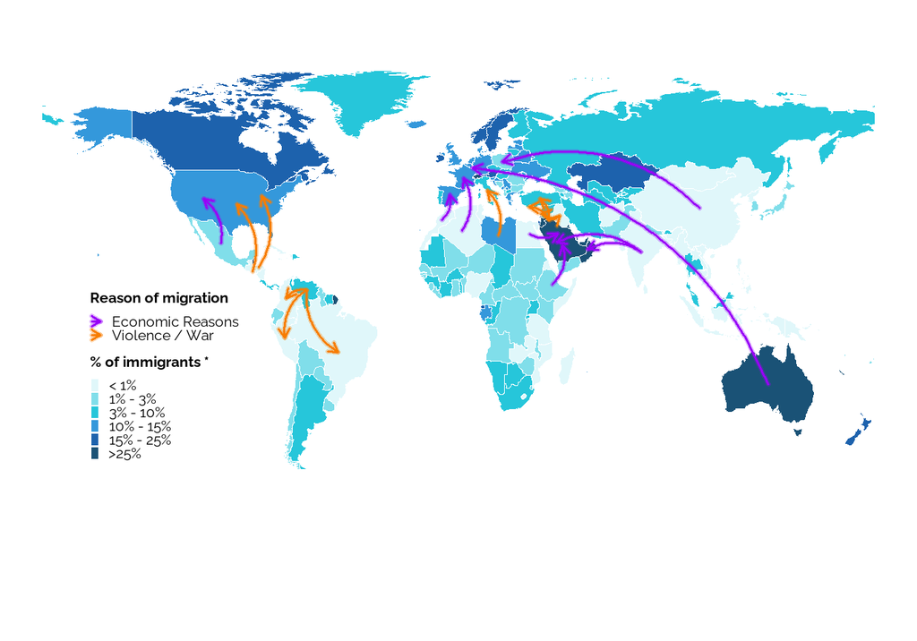

```r
#New categories
datos_mapa$Percent_Migration_category <- cut(
 datos_mapa$Percent_Migration,
 breaks = c(-Inf, 1, 3, 10, 15, 25, Inf),
 labels = c("< 1%", "1% - 3%", "3% - 10%", "10% - 15%", "15% - 25%", ">25%"),
 right = FALSE)

map_2 <- ggplot() +
  geom_sf(data = datos_mapa,
          aes(fill = Percent_Migration_category),
          color = "white", linewidth = 0.2) +
  scale_fill_manual(
    values = c(
      "< 1%" = "#e0f7fa",
      "1% - 3%" = "#80deea",
      "3% - 10%" = "#26c6da",
      "10% - 15%" = "#3498db",
      "15% - 25%" = "#1d62ad",
      ">25%" = "#1a5276"
    ),
    name = "% of immigrants *",
    na.translate = FALSE,
    na.value = "gray80"
  ) +

  # Flechas con efecto de grosor manual
  geom_curve(data = flows,
             aes(x = origin_lon, y = origin_lat,
                 xend = dest_lon, yend = dest_lat,
                 color = reason),
             curvature = 0.3,  # Arrow curvature
             arrow = arrow(length = unit(0.08, "inches"), type = "open"),
             linewidth = 0.7,  #Arrow line width
             lineend = "round") +
  geom_curve(data = flows,
             aes(x = origin_lon, y = origin_lat,
                 xend = dest_lon, yend = dest_lat,
                 color = reason),
             curvature = 0.3,
             arrow = arrow(length = unit(0.08, "inches"), type = "open"),
             linewidth = 1.4,  #Effect line width
             alpha = 0.3,
             lineend = "round") +

  # Reasons of migration
  scale_color_manual(
    values = c("Violence / War" = "#f77d00",
               "Economic Reasons" = "#9800f7"),
    name = "Reason of migration"
  ) +

  # Theme and legens
  theme_void() +
  theme(
    legend.position = c(0.18, 0.4),
    legend.title = element_text(size = 8, face = "bold", family = "raleway"),
    legend.key.size = unit(0.07, "cm"),
    legend.key.height = unit(0.17, "cm"),
    legend.key.width = unit(0.17, "cm"),
    legend.box.spacing = unit(0.07, "cm"),
    legend.text = element_text(size = 8, family = "raleway"),
    aspect.ratio = 0.6
  ) +
  coord_sf()

map_2
```

## We create the *BAR PLOTS*

> We do the same as before with the original barplot, but now for countries with less immigrants, and just taking into account the 5 countries and not 8.

```r
# We load the flags
flag_china <- readPNG("C:/Users/menci/OneDrive/Escritorio/R STUDIO/DATA VISUALIZATION/TRABAJO FINAL/BANDERAS/china.png")
flag_vietnam <- readPNG("C:/Users/menci/OneDrive/Escritorio/R STUDIO/DATA VISUALIZATION/TRABAJO FINAL/BANDERAS/vietnam.png")
flag_cuba <- readPNG ("C:/Users/menci/OneDrive/Escritorio/R STUDIO/DATA VISUALIZATION/TRABAJO FINAL/BANDERAS/cuba.png")
flag_madagascar <- readPNG ("C:/Users/menci/OneDrive/Escritorio/R STUDIO/DATA VISUALIZATION/TRABAJO FINAL/BANDERAS/madagascar.png")
flag_indonesia <- readPNG ("C:/Users/menci/OneDrive/Escritorio/R STUDIO/DATA VISUALIZATION/TRABAJO FINAL/BANDERAS/indonesia.png")
```

> We do again the bar plot for countries with more immigrants, but just taking into account 5

```r
bar_plot1 <- datos_mapa |>
  arrange(desc(Percent_Migration)) |>
  head(5) |>
  ggplot(aes(x = reorder(Country, Percent_Migration), y = Percent_Migration, fill = Percent_Migration)) +
  geom_bar(stat = "identity", fill="#3498db",  width = 0.7) +
  geom_text(
    aes(label = paste0(format(round(Percent_Migration, 2), nsmall = 2), "%")),
    hjust = 0,  # Text position
    nudge_y = 2, #Space between bars and percentage
    size = 2
  )+
  coord_flip() +  # Horizontal
  labs(
    title = "Countries with more immigrants",
  ) +
  scale_y_continuous(expand = expansion(mult = c(0.05, 0.05)))+ #Space between bars
  theme_minimal() +
  theme(
    axis.text.x = element_blank(),  # Eliminate text in axis X
    axis.text.y = element_text(size = 7,  margin = margin(r = 10), family = "raleway"),   # Margin (for the flags)
    axis.title.x = element_blank(),  # Eliminate the title in axis X
    axis.title.y = element_blank(),  # Eliminate the title in axis X
    panel.grid = element_blank(),
    axis.line = element_blank(),
    legend.position = "none",
    aspect.ratio = 1.8,#more or less compressed
    plot.title = element_text(
      size = 6,
      face = "bold",
      family = "raleway",
      hjust = 0.5
    ))

# With the flags:
graph_1 <- bar_plot1 +
  annotation_raster(flag_eau, xmin = 4.75, xmax = 5.3, ymin = -30, ymax = -5)+
  annotation_raster(flag_kuwait, xmin = 3.75, xmax = 4.3, ymin = -30, ymax = -5)+
  annotation_raster(flag_bvi, xmin = 2.75, xmax = 3.3, ymin = -30, ymax = -5) +
  annotation_raster(flag_qatar, xmin = 1.75, xmax = 2.3, ymin = -30, ymax = -5) +
  annotation_raster(flag_isleofman, xmin = 0.75, xmax = 1.3, ymin = -30, ymax = -5) +
  coord_flip(clip = "off")
```

[output not shown]

[figure not shown]

```r
graph_1
```

> Now for the countries with less immigrants:

```r
bar_plot2 <- datos_mapa |>
  arrange(Percent_Migration) |>
  head(5) |>
  ggplot(aes(x = reorder(Country, -Percent_Migration), y = Percent_Migration, fill = Percent_Migration)) +
  geom_bar(stat = "identity", fill="#3498db",  width = 0.7) +
  geom_text(
    aes(label = if_else(Percent_Migration < 0.01,
                        "<0.01%",
                        paste0(format(round(Percent_Migration, 2), nsmall = 2), "%"))),
    hjust = 0,  # Text position
    nudge_y = 2, #Space between bars and percentage
    size = 2
  )+
  coord_flip() +  # Horizontal
  labs(
    title = "Countries with less immigrants",
  ) +
  scale_y_continuous(expand = expansion(mult = c(0.05, 0.05)))+ #Space between bars
  theme_minimal() +
  theme(
    axis.text.x = element_blank(),  # Eliminate text in axis X
    axis.text.y = element_text(size = 7,  margin = margin(r = 8), family = "raleway"),   # Margin (for the flags)
    axis.title.x = element_blank(),  # Eliminate the title in axis X
    axis.title.y = element_blank(),  # Eliminate the title in axis X
    panel.grid = element_blank(),
    axis.line = element_blank(),
    legend.position = "none",
    aspect.ratio = 1.8,#more or less compressed
    plot.title = element_text(
      size = 6,
      face = "bold",
      family = "raleway",
      hjust = 0.5
    )
  )

# With the flags
graph_2 <- bar_plot2 +
  annotation_raster(flag_china, xmin = 4.8, xmax = 5.3, ymin = -1.2, ymax = -0.2)+
  annotation_raster(flag_vietnam, xmin = 3.8, xmax = 4.3, ymin = -1.2, ymax = -0.2)+
  annotation_raster(flag_cuba, xmin = 2.8, xmax = 3.3, ymin = -1.2, ymax = -0.2) +
  annotation_raster(flag_madagascar, xmin = 1.8, xmax = 2.3, ymin = -1.2, ymax = -0.2) +
  annotation_raster(flag_indonesia, xmin = 0.8, xmax = 1.3, ymin = -1.2, ymax = -0.2) +
  coord_flip(clip = "off")
```

[output not shown]

[figure not shown]

```r
graph_2
```

> **IMPORTANT**: Just as before the barplots look a bit “ugly” because the he flags appear on top of the text blocking it and also because the letters and numbers and letters look tiny, but in the final plot the bar plots appear adjusted

# FINAL PLOT WITH IMPROVEMENTS (BEFORE IÑAKI’S ADVICE)

> Now we want to join the map with both barplots. We do the same as before:

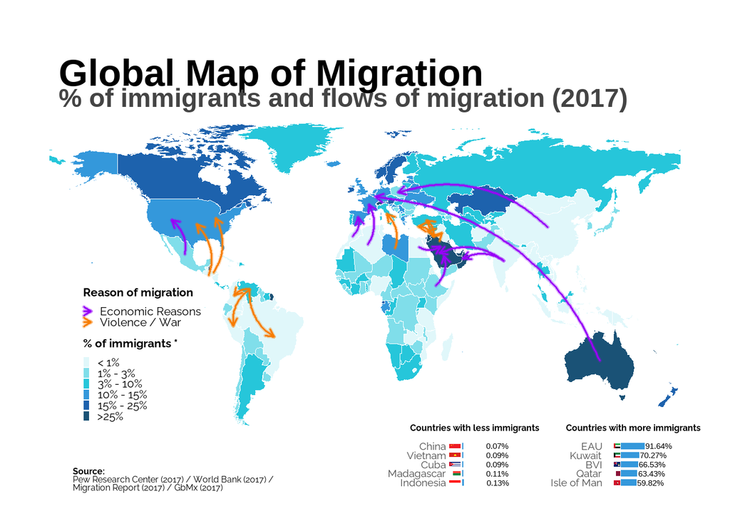

```r
# We load the images and create grobs
map_grob <- ggplotGrob(map_2)
graph_grob <- ggplotGrob(graph_1)
graph2_grob <- ggplotGrob(graph_2)

# We bind map + barplot1 + barplot2 + image
final_plot <- ggdraw() +
  draw_grob(map_grob) +
  draw_grob(graph_grob, x = 0.72, y = 0.05, width = 0.2, height = 0.2) +
  draw_grob(graph2_grob, x = 0.5, y = 0.05, width = 0.2, height = 0.2) +
  draw_grob(
    textGrob(
      "Source:",
      x = 0.1, y = 0.12,
      gp = gpar(fontface = "bold", fontsize = 6, fontfamily = "raleway"),
      hjust = 0
    )
  ) +
  draw_grob(
    textGrob(
      "Pew Research Center (2017) / World Bank (2017) /",
      x = 0.1, y = 0.1,
      gp = gpar(fontsize = 6, fontfamily = "raleway"),
      hjust = 0
    )
  )+
  draw_grob(
    textGrob(
      "Migration Report (2017) / GbMx (2017)",
      x = 0.1, y = 0.08,
      gp = gpar(fontsize = 6, fontfamily = "raleway"),
      hjust = 0
    )
  )
# We add the title
plot <- plot_grid(
  ggdraw() +
    draw_text("Global Map of Migration", size = 26, x = 0.08, y = 0.3, hjust = 0, fontface = "bold") +
    draw_text("% of immigrants and flows of migration (2017)", size = 18, x = 0.08, y = 0.06, hjust = 0, fontface = "bold", color = "#444444"),
  final_plot,
  ncol = 1,
  rel_heights = c(0.2, 0.8)
)
plot
```

# MAP WITH IÑAKI’S ADVICE

> Here I tried to apply Iñaki’s advice (professor) to improve the plot, specifically I take into account these suggestion:
> 1. Avoid categories and make the “% of immigrants” continuous since we have this data.
> 2. Flip the color scale (blue for low values and yellow for high values)

> **PROBLEM**: If we do the plot continuous the map would look blue because the mayority of countries have less than 25% of immigration, as we can see:

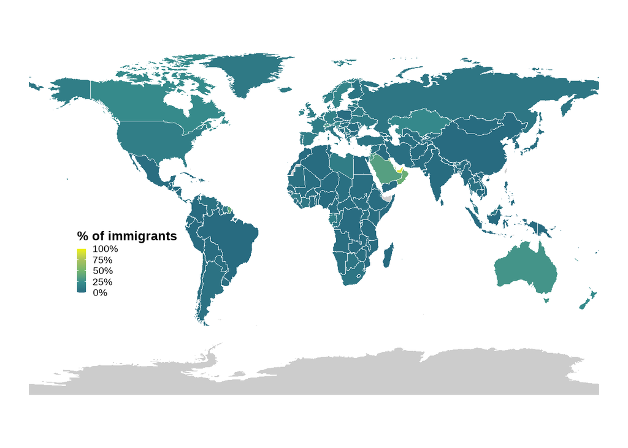

```r
linear_scale_colors <- scale_fill_gradientn(
  colors = c("#286b80", "#388f8d", "#72b56e", "#aac25c", "#eef100"),
  na.value = "gray80",
  name = "% of immigrants",
  limits = c(0, 100),
  breaks = c(0, 25, 50, 75, 100),
  labels = c("0%", "25%", "50%", "75%", "100%")
)

map_cont <- ggplot() +
  geom_sf(data = datos_mapa,
          aes(fill = Percent_Migration),
          color = "white", linewidth = 0.2)+
  theme_void() +
  linear_scale_colors+
  theme(
    legend.position = c(0.2, 0.4),
    legend.title = element_text(size = 10, face = "bold"),
    legend.key.size = unit(0.15, "cm"),
    legend.key.height = unit(0.25, "cm"),
    legend.key.width = unit(0.25, "cm"),
    legend.text = element_text(size = 8),
    aspect.ratio = 0.6
  ) +
  coord_sf()

map_cont
```

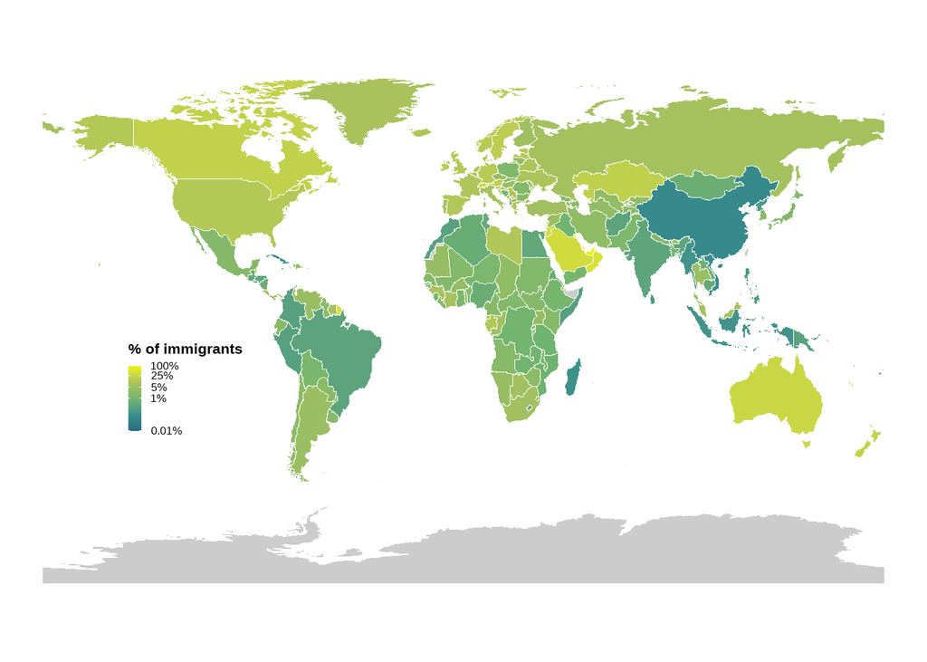

```r
log_scale_colors <- scale_fill_gradientn(
  colors = c("#286b80", "#388f8d", "#72b56e", "#aac25c", "#eef100"),
  trans = "log10",  # logarithmic scale
  na.value = "gray80",
  limits = c(0.01, 100),
  name = "% of immigrants",
  breaks = c(0.01, 1, 5, 25, 100),  #since it's logarithmic we can not star from 0
  labels = c("0.01%", "1%", "5%", "25%", "100%")
)

# logarithmic MAP
map_log <- ggplot() +
  geom_sf(data = datos_mapa,
          aes(fill = Percent_Migration),
          color = "white", linewidth = 0.2) +
  log_scale_colors +
  theme_void() +
  theme(
    legend.position = c(0.2, 0.4),
    legend.title = element_text(size = 8, face = "bold"),
    legend.key.size = unit(0.15, "cm"),
    legend.key.height = unit(0.25, "cm"),
    legend.key.width = unit(0.25, "cm"),
    legend.text = element_text(size = 6),
    aspect.ratio = 0.6
  ) +
  coord_sf()

map_log
```

# QUESTIONS

> Before continuing the plot (joining it with the bar plots), what do you think about the logarithmic scale? I think that thanks to it we can highight better the differences than with the continuous scale. Also, I think it’s better -as you said- that the blue and dark colors are related to lower values and the higher values are represented with more lighter and yellowish colors.

> Other example: if we see Canada we could also have some doubts about the € of immigration, while with the categorical scale it’s clear that it’s more clear that it has between 15 and 25% of immigration